# Time Series Regression for Predicting Macroeconomic Indicator: Second Hand House Sale

Umut Mustafa Dilsiz

05 05 2021

# Introduction

In this assignment, our aim is to develop and analyze a time series regression model to estimate the parameters that we will consider macroeconomically such as “Second hand home sales”. We will use the different types of data we have to evaluate to create a valid and useful model. First of all, I would like to express that all the data we will use to express the situation clearly are taken from the Central Bank of the Republic of Turkey Electronic Data Distribution System: [EVDS] (https://evds2.tcmb.gov.tr/). To estimate the “second hand home purchase” index for April 2021; Previous “second hand home purchases”, dollar exchange rates as prices are usually set in dollars, we can take survey questions to measure the impact of the economy on people. There are two different survey questions. The first of these measures the probability of buying a second-hand home in the next 12 months, the other measures the general economic situation expectation for the next 12 months. In the homework, each data will be analyzed and their connections with each other will be checked.

```
## Rows: 86
## Columns: 6
## $ Date                         <date> 2014-01-01, 2014-02-01, 2014-03-01, 2...
## $ Exchange_Rate                <dbl> 2.216836, 2.212760, 2.217795, 2.127471...
## $ Prob_Buying_Home             <dbl> 10.383443, 8.610124, 12.020289, 11.001...
## $ General_Economic_Expectation <dbl> 94.03358, 90.37099, 95.86817, 107.0131...
## $ Second_Hand_Sale             <dbl> 64.1, 64.8, 65.7, 66.8, 67.5, 68.2, 69...
## $ Interest_Rate                <dbl> 11.3000, 13.0300, 13.5050, 13.5200, 12...
```

# Analysis of Second Hand Sale: Main Function

Understanding of the main function, index of Second Hand Sale, plotting could be an option to reach a better point.

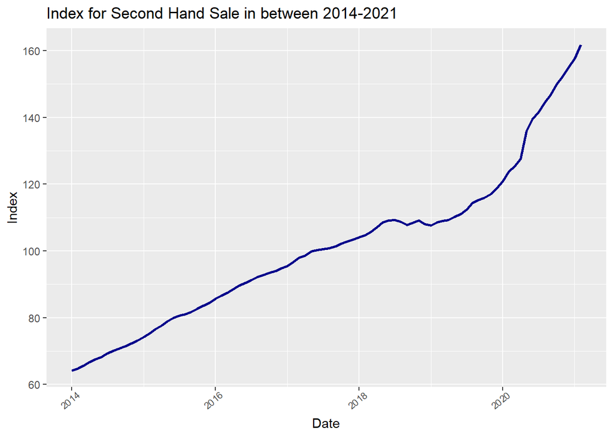

As can be seen on the chart, it is not very easy to place a clear trend line. because there is an increasing and decreasing line. We can use the logarithm function to find a better trend.

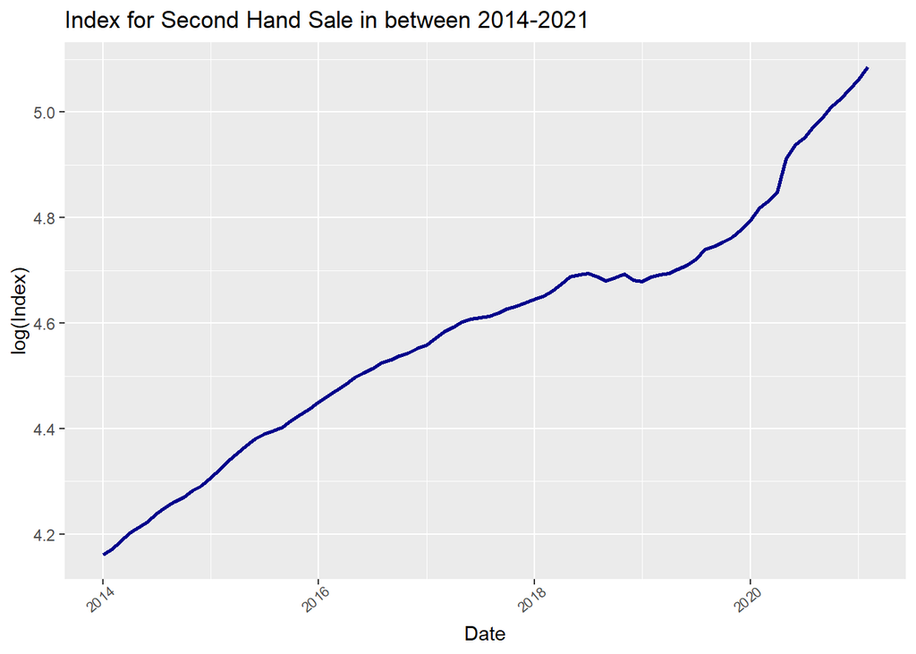

Let’s add trend lines to see which graphic will work better.

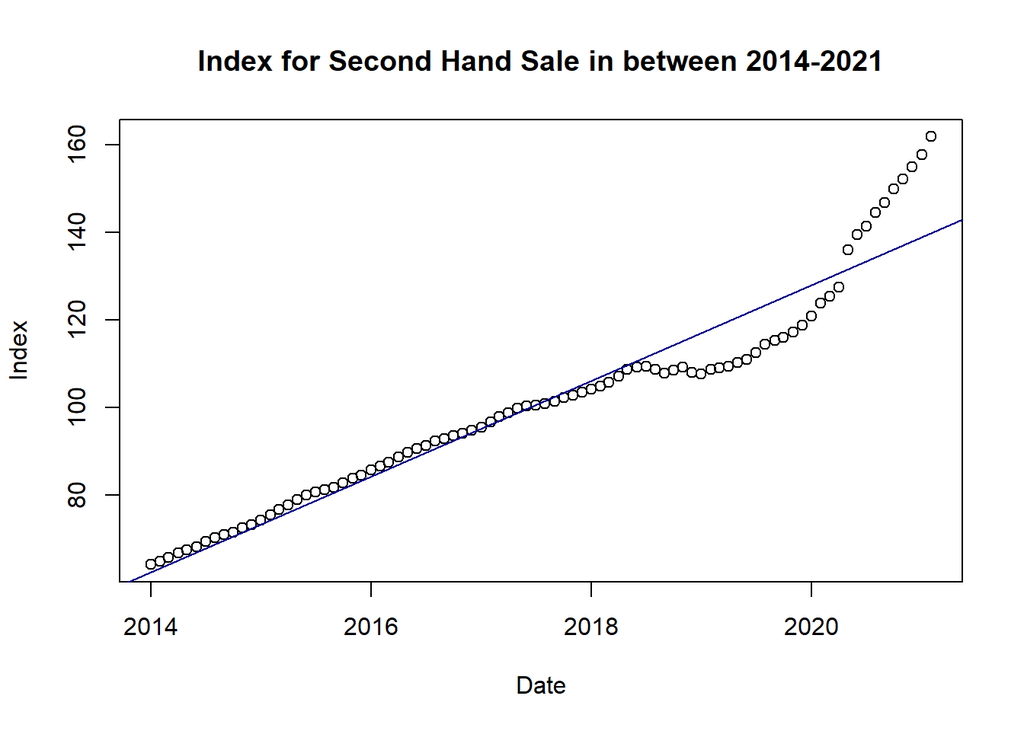

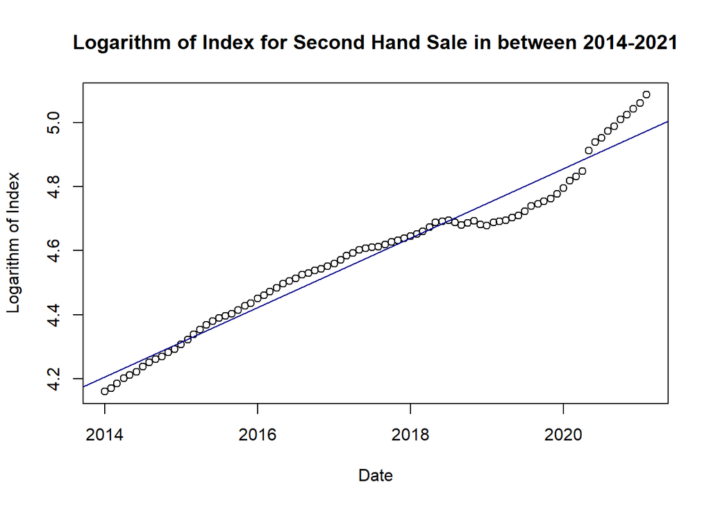

Since the trend line is closer in the logarithm chart than in the normal chart, it is more accurate to base it. It is not correct to say that the logarithm plot is definitely better, as other types of trends can affect our prediction model. However, it is more likely to be predictable. As a result of trend lines graphs, it seems better to create a forecast model in the logarithm version.

# Analyses of All Variables

First of all, it is necessary to specify the relationships of the data we use. Exchange rates are one of the factors that affect the buying and selling power in the country. An increase in the exchange rate means that it may lead to a decrease in purchasing power. Interest rates are another factor that shows the strength of the country’s economy. Other data include two different survey results. In the second hand home buying survey, “What are your chances of buying a second hand home in the next 12 months?” We can find the answer to the question. In the other survey, "What are your expectations for the general economic situation in the next 12 months? We can reach the answers to the question. Let’s evaluate on the same graph to see if there are significant similarities between the data. Since the values of some data are high, a certain amount of reduction has been made.

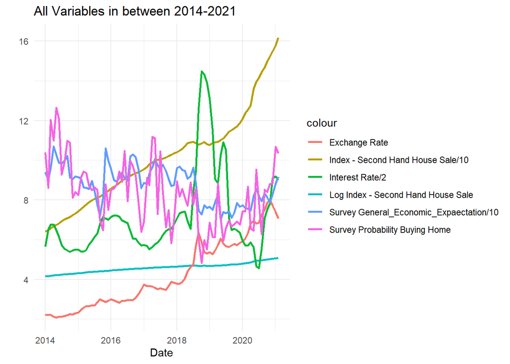

[figure not shown]

In this part, the correlation between second-hand home purchasing and other variables and the correlation between the logarithm of second-hand home purchasing and other variables were compared. It would make sense to go with the logarithm option to generate a good estimate.

# Forecasting Model

```r
corredata=data.table(corredata)
Fr=lm( log_sc ~ Dollar + Prob_buying + General_eco + IntRate, corredata)
summary(Fr)
```

```
##
## Call:
## lm(formula = log_sc ~ Dollar + Prob_buying + General_eco + IntRate,
##     data = corredata)
##
## Residuals:
##      Min       1Q   Median       3Q      Max
## -0.15685 -0.04619  0.01061  0.04771  0.12679
##
## Coefficients:
##              Estimate Std. Error t value Pr(>|t|)
## (Intercept)  3.657672   0.113906  32.111  < 2e-16 ***
## Dollar       0.143796   0.005509  26.100  < 2e-16 ***
## Prob_buying -0.022697   0.006087  -3.729 0.000355 ***
## General_eco  0.006636   0.001228   5.405 6.36e-07 ***
## IntRate     -0.004842   0.001939  -2.498 0.014519 *
## ---
## Signif. codes:  0 '***' 0.001 '**' 0.01 '*' 0.05 '.' 0.1 ' ' 1
##
## Residual standard error: 0.06583 on 81 degrees of freedom
## Multiple R-squared:  0.9217, Adjusted R-squared:  0.9179
## F-statistic: 238.5 on 4 and 81 DF,  p-value: < 2.2e-16
```

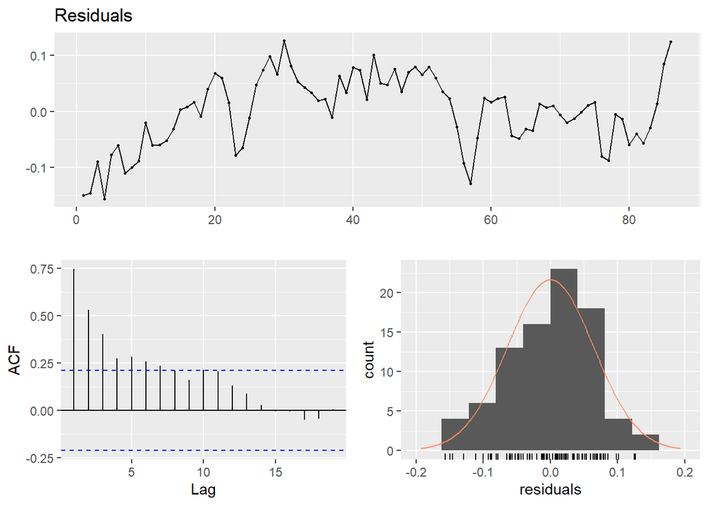

```
##
##  Breusch-Godfrey test for serial correlation of order up to 10
##
## data:  Residuals
## LM test = 59.003, df = 10, p-value = 5.594e-09
```

```r
checkresiduals(Fr)
```

#Residuals for Fitted Value

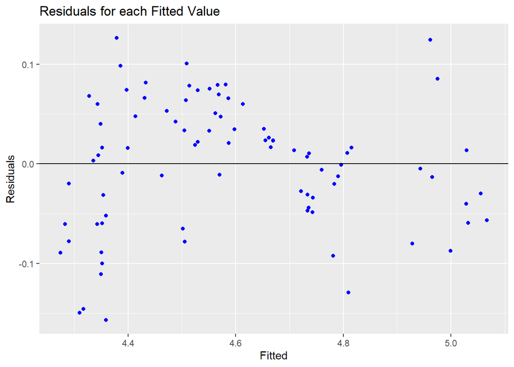

#Actual & Fitted Value

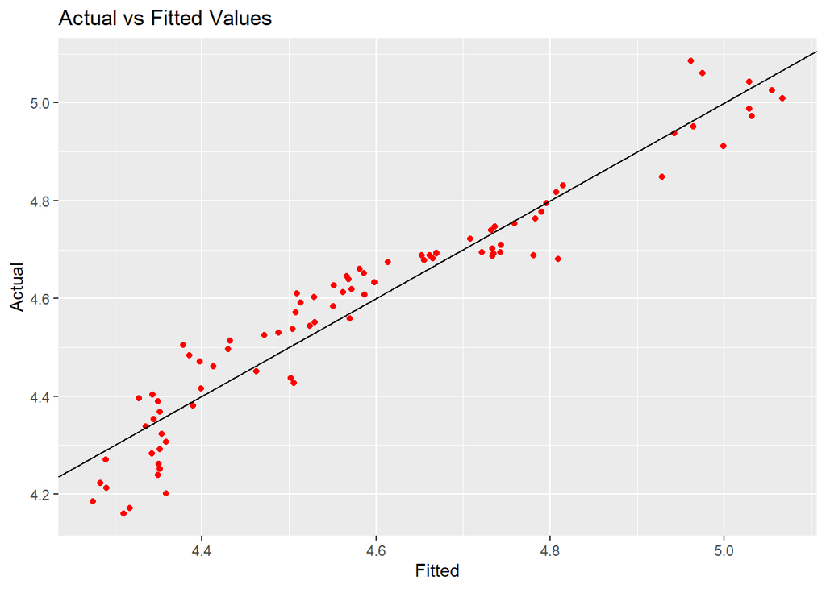

When we observe the graph, it seems possible that it can be compared with the real index.